# R Notebook

```r
library(tidyverse)

data <- read_csv("Datacamp_Supermarket/loyalty.csv")

clean_data <- data %>%
    mutate(
        first_month = ifelse(first_month == ".", 0, first_month),
        region = factor(region, levels = c('Americas', 'Asia/Pacific', 'Europe', 'Middle East/Africa')),
        loyalty_years = factor(loyalty_years, order = TRUE, levels = c('0-1', '1-3', '3-5', '5-10', '10+')),
        joining_month = ifelse(is.na(joining_month) , "Unknown", joining_month),
        promotion = case_when(promotion == "YES" ~ "Yes",
                              promotion == "NO" ~ "No",
                             TRUE ~ promotion)
    ) %>%
    mutate(
        first_month = as.numeric(first_month),
        joining_month = factor(joining_month, levels = c("Jan", "Feb", 'Mar', 'Apr', 'May', 'Jun', 'Jul', 'Aug', 'Sep', 'Oct', 'Nov', 'Dec', 'Unknown')),
        promotion = factor(promotion, levels = c("No", "Yes"))
    )
clean_data
```

| customer_id | spend | first_month | items_in_first_month | region | loyalty_years | joining_month | promotion |
| --- | --- | --- | --- | --- | --- | --- | --- |
| 0001 | 132.68 | 15.30 | 5 | Asia/Pacific | 5-10 | Nov | No |
| 0002 | 106.45 | 16.20 | 14 | Asia/Pacific | 0-1 | Feb | Yes |
| 0003 | 123.16 | 25.26 | 7 | Middle East/Africa | 10+ | Dec | Yes |
| 0004 | 130.60 | 24.74 | 8 | Middle East/Africa | 3-5 | Apr | No |
| 0005 | 130.41 | 25.59 | 8 | Middle East/Africa | 3-5 | Apr | Yes |
| 0006 | 127.46 | 21.45 | 7 | Europe | 3-5 | May | Yes |
| 0007 | 127.17 | 21.46 | 14 | Middle East/Africa | 3-5 | Unknown | No |
| 0008 | 125.50 | 19.11 | 7 | Asia/Pacific | 3-5 | Jul | Yes |
| 0009 | 106.80 | 16.01 | 14 | Americas | 0-1 | Feb | Yes |
| 0010 | 112.28 | 21.49 | 7 | Europe | 0-1 | May | No |

[output cut: 990 more lines]

```r
summary(clean_data)
```

```
 customer_id            spend        first_month    items_in_first_month                region
 Length:1246        Min.   :104.3   Min.   : 0.00   Min.   : 5.000       Americas          :309
 Class :character   1st Qu.:112.2   1st Qu.:15.75   1st Qu.: 7.000       Asia/Pacific      :291
 Mode  :character   Median :123.8   Median :19.12   Median : 9.000       Europe            :320
                    Mean   :122.6   Mean   :17.16   Mean   : 9.418       Middle East/Africa:326
                    3rd Qu.:131.1   3rd Qu.:21.28   3rd Qu.:13.000
                    Max.   :142.3   Max.   :26.20   Max.   :15.000

 loyalty_years joining_month promotion
 0-1 :382      Jan    :146   No :635
 1-3 :241      Unknown:125   Yes:611
 3-5 :256      Jul    :111
 5-10:250      Feb    :109
 10+ :117      Oct    :107
               May    : 96
               (Other):552
```

```r
levels(clean_data$joining_month)
```

```
 [1] "Jan"     "Feb"     "Mar"     "Apr"     "May"     "Jun"     "Jul"     "Aug"     "Sep"     "Oct"
[11] "Nov"     "Dec"     "Unknown"
```

# Task 2

The team at International Essentials have told you that they have always believed that the number of years in the loyalty scheme is the biggest driver of spend.

Producing a table showing the difference in the average spend by number of years in the loyalty programme along with the variance to investigate this question for the team.

You should start with the data in the file ‘loyalty.csv’. Your output should be a data frame named spend_by_years. It should include the three columns loyalty_years, avg_spend, var_spend. Your answers should be rounded to 2 decimal places.

```r
spend_by_years <- data %>%
  group_by(loyalty_years) %>%
  summarize(
    avg_spend = round(mean(spend),2),
    var_spend = round(var(spend),2)
  ) %>%
  select(loyalty_years, avg_spend, var_spend)

spend_by_years
```

| loyalty_years | avg_spend | var_spend |
| --- | --- | --- |
| 0-1 | 110.56 | 9.30 |
| 1-3 | 129.31 | 9.65 |
| 10+ | 117.41 | 16.72 |
| 3-5 | 124.55 | 11.09 |
| 5-10 | 135.15 | 14.10 |

Task 3 Fit a baseline model to predict the spend over the year for each customer.

Fit your model using the data contained in “train.csv”

```r
train <- read_csv("Datacamp_Supermarket/train.csv") %>%
  mutate(
    loyalty_years = factor(loyalty_years, order = TRUE, levels = c('0-1', '1-3', '3-5', '5-10', '10+')))


model <- lm(spend~loyalty_years * first_month + items_in_first_month + joining_month, data = train)
summary(model)
```

```
Call:
lm(formula = spend ~ loyalty_years * first_month + items_in_first_month +
    joining_month, data = train)

Residuals:
     Min       1Q   Median       3Q      Max
-0.77327 -0.16607 -0.01712  0.12024  2.63223

Coefficients:
                              Estimate Std. Error  t value Pr(>|t|)
(Intercept)                  1.352e+02  8.713e-01  155.186   <2e-16 ***
loyalty_years.L              1.041e+01  1.496e-01   69.585   <2e-16 ***
loyalty_years.Q              1.066e+01  1.218e-01   87.495   <2e-16 ***
loyalty_years.C             -4.666e+01  1.214e-01 -384.287   <2e-16 ***
loyalty_years^4              3.649e+01  1.156e-01  315.571   <2e-16 ***
first_month                 -6.867e-02  3.208e-02   -2.141   0.0325 *
items_in_first_month        -3.008e-02  2.256e-02   -1.334   0.1827
joining_monthAug            -3.112e+00  1.190e-01  -26.152   <2e-16 ***
joining_monthDec            -3.644e+00  1.282e-01  -28.434   <2e-16 ***
joining_monthFeb            -1.077e+01  3.301e-01  -32.628   <2e-16 ***
joining_monthJan            -1.508e+01  4.815e-01  -31.323   <2e-16 ***
joining_monthJul            -5.399e+00  1.898e-01  -28.450   <2e-16 ***
joining_monthJun            -5.501e+00  1.729e-01  -31.811   <2e-16 ***
joining_monthMar            -9.258e+00  2.923e-01  -31.675   <2e-16 ***
joining_monthMay            -2.724e+00  1.150e-01  -23.679   <2e-16 ***
joining_monthNov            -1.216e+01  3.758e-01  -32.347   <2e-16 ***
joining_monthOct            -7.811e+00  2.761e-01  -28.287   <2e-16 ***
joining_monthSep            -5.609e+00  2.188e-01  -25.641   <2e-16 ***
loyalty_years.L:first_month -6.795e-03  7.518e-03   -0.904   0.3663
loyalty_years.Q:first_month -7.050e-03  6.244e-03   -1.129   0.2591
loyalty_years.C:first_month -5.027e-03  6.256e-03   -0.804   0.4219
loyalty_years^4:first_month  4.138e-04  5.929e-03    0.070   0.9444
---
Signif. codes:  0 ‘***’ 0.001 ‘**’ 0.01 ‘*’ 0.05 ‘.’ 0.1 ‘ ’ 1

Residual standard error: 0.3064 on 974 degrees of freedom
Multiple R-squared:  0.9999,    Adjusted R-squared:  0.9999
F-statistic: 3.632e+05 on 21 and 974 DF,  p-value: < 2.2e-16
```

```r
test <- read_csv("Datacamp_Supermarket/test.csv")


base_result <- test %>%
  select(customer_id) %>%
  mutate(spend = seq(1:n()))

base_result$spend <- predict(model, newdata = test)



# rmse <- round(sqrt(mean((train$spend - base_result$spend)^2)),3)
#
# # Mostrar el resultado
# print(rmse)
```

Task 4 Fit a comparison model to predict the spend over the year for each customer.

Fit your model using the data contained in “train.csv”

Use “test.csv” to predict new values based on your model. You must return a dataframe named compare_result, that includes customer_id and spend. The spend column must be your predicted values.

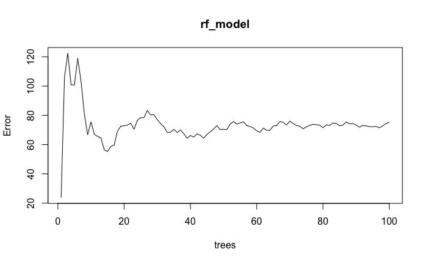

```r
library(randomForest)
# Codificar loyalty_years como ordinal numérico
loyalty_levels <- c("0-1", "1-3", "3-5", "5-10", "10+")
train <- train %>%
  mutate(loyalty_encoded = as.numeric(factor(loyalty_years, levels = loyalty_levels, ordered = TRUE)))

test <- test %>%
  mutate(loyalty_encoded = as.numeric(factor(loyalty_years, levels = loyalty_levels, ordered = TRUE)))

# Seleccionar variables
features <- c("loyalty_encoded", "first_month", "items_in_first_month", "joining_month")

# Ajustar modelo Random Forest
rf_model <- randomForest(x = train[, features], y = train$spend, ntree = 100)


plot(rf_model)
```

```r
# Predecir sobre test
predicted_spend <- predict(rf_model, newdata = test[, features])

# Construir resultado final
compare_result <- test %>%
  select(customer_id) %>%
  mutate(spend = predicted_spend)
```